# Lab06

Yifei Liu

10/05/2021

## Task 1: Build tree and make comments

Below you will see the data being loaded, the is_spam column turned into a factor (so the tree uses gini loss function instead of entropy). I decided not to use the pruned/existence of words version because there are no major differences in shape and performance.

The shape of the tree indicates that at each split, the tree is choosing a ‘spam’ as the criteria and splitting the dataset based on the existence of the ‘spam’ word. All texts that contain the ‘spam’ word are categorized as spam and branched to the right, while all the ‘safe’ texts are branched to the left. This process is repeated until 15 ‘spam’ words have been decided. (Further splits will only result in neglible increase in performance.)

```r
library(rpart)
load("spam.rda")
all_data <- data.frame(df$is_spam, wordmatrix)
names(all_data)[1] <- "is_spam"

tree_binary <- rpart(factor(is_spam)~., data=all_data)
printcp(tree_binary)
```

```
##
## Classification tree:
## rpart(formula = factor(is_spam) ~ ., data = all_data)
##
## Variables actually used in tree construction:
##  [1] w_awarded    w_Call       w_claim      w_collection w_Free
##  [6] w_FREE       w_me         w_mobile     w_PO         w_Reply
## [11] w_service    w_STOP       w_Text       w_Txt        w_www
##
## Root node error: 747/5574 = 0.13402
##
## n= 5574
##
##          CP nsplit rel error  xerror     xstd
## 1  0.153949      0   1.00000 1.00000 0.034048
## 2  0.104418      1   0.84605 0.84605 0.031689
## 3  0.088353      2   0.74163 0.74163 0.029902
## 4  0.065596      3   0.65328 0.65328 0.028248
## 5  0.060241      4   0.58768 0.61580 0.027501
## 6  0.044177      5   0.52744 0.54886 0.026090
## 7  0.042838      6   0.48327 0.51673 0.025374
## 8  0.028112      7   0.44043 0.44043 0.023554
## 9  0.022758      8   0.41232 0.42838 0.023250
## 10 0.021419      9   0.38956 0.41098 0.022801
## 11 0.014279     10   0.36814 0.39625 0.022412
## 12 0.013387     13   0.32530 0.38420 0.022087
## 13 0.010000     15   0.29853 0.36412 0.021533
```

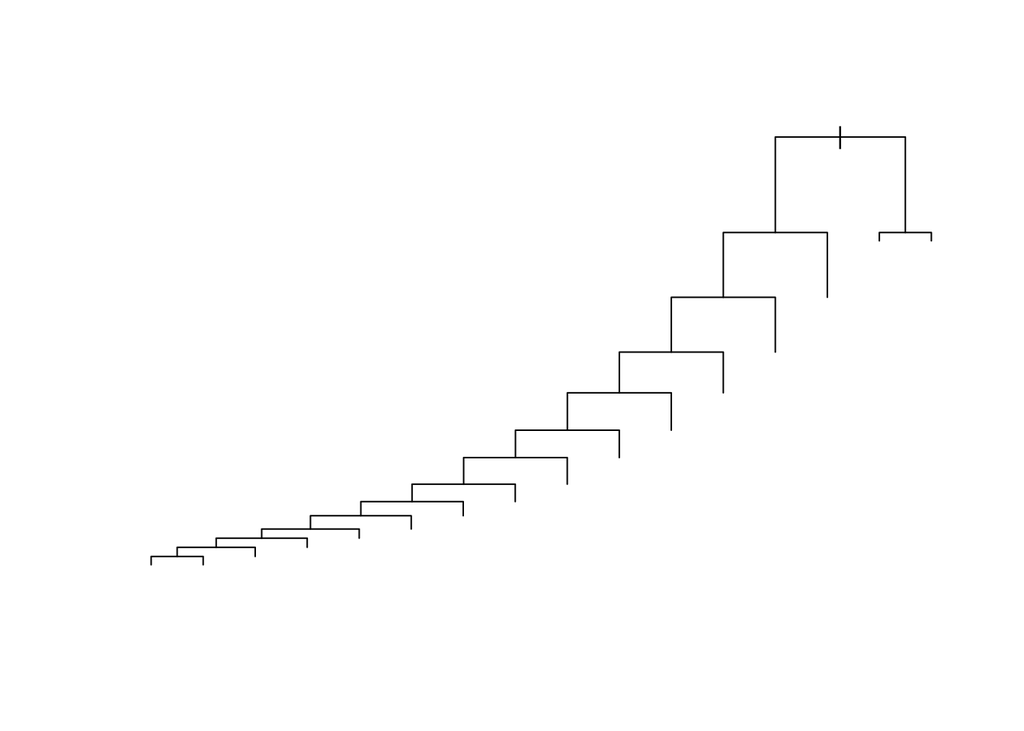

```r
plot(tree_binary)
```